# Bayesian models for paired comparisons and rankings with RBBayes

A hands-on tutorial

Lapo Santi and Nial Friel

# 1 Before you start

This tutorial follows the presentation’s BT, BT–SBM and PL practicals. Each practical comes after the corresponding model’s theory session. The tutorial and presentation contain separate copies of the same analysis code, with matching chunk labels and seeds. Neither file reads code from the other.

For downloads and a complete setup guide, including the working directory, start at the [website Tutorial page](https://lapo-santi.github.io/RBBayes/tutorial.html).

Run the chunks in order in RStudio, or use *Knit* to generate the complete HTML document. Matching R/package versions and optional packages are needed for matching Monte Carlo results. Plot dimensions differ between the two formats. Runtime depends on the computer.

**Installation (run once).** The code below installs the GitHub development version while the package is being prepared for CRAN. Building its C++ code from source requires standard R build tools. If these are not already installed:

> **Windows:** install the [Rtools version matching your R version](https://cran.r-project.org/bin/windows/Rtools/), then restart RStudio.

> **macOS:** run `xcode-select --install` in **Terminal**, then complete the installation dialogue. The [Xcode Command Line Tools](https://developer.apple.com/documentation/xcode/installing-the-command-line-tools/) are sufficient; the full Xcode application is not required.

> These tools are needed for the source installation below. An available CRAN binary normally does not require compiling the package yourself.

```r
install.packages(c("remotes", "ggplot2", "knitr", "rmarkdown"))
remotes::install_github("lapo-santi/RBBayes")

# Optional: coda and bayesplot enable their sections; salso enables its
# partition search (a built-in search is used when salso is absent).
install.packages(c("coda", "bayesplot", "salso"))
```

## 1.1 Where to find this tutorial after installation

Package installation stores the tutorial in the `tutorial` folder **inside the installed RBBayes package**, alongside its other resources. It does not create a Desktop file or automatically open an RStudio tab. The exact package library location depends on the computer; use `system.file()` to find it. This hands-on tutorial is a bundled file, so it is not listed by `vignette()`.

**Read the finished tutorial in a browser:**

```r
browseURL(system.file("tutorial", "RBBayes-tutorial.html",
                      package = "RBBayes", mustWork = TRUE))
```

**Copy the editable source into your current project and open it:**

```r
tutorial_source <- system.file("tutorial", "RBBayes-tutorial.Rmd",
                               package = "RBBayes", mustWork = TRUE)
if (!file.exists("RBBayes-tutorial.Rmd")) {
  stopifnot(file.copy(tutorial_source, "RBBayes-tutorial.Rmd"))
}
file.edit("RBBayes-tutorial.Rmd")
```

The copy appears in the folder returned by `getwd()` and should open in RStudio’s Source pane. The code preserves an existing file of that name; choose a new project folder if you need a fresh copy without replacing your work. Running these commands is a separate step after installing the package.

```r
library(RBBayes)
library(dplyr)
library(tidyr)
library(ggplot2)
has_coda <- requireNamespace("coda", quietly = TRUE)
has_bayesplot <- requireNamespace("bayesplot", quietly = TRUE)
packageVersion("RBBayes")
```

```
## [1] '1.0.0'
```

**What you will do.**

1. **BT:** simulate comparisons with one distinct generating strength per player; prepare the edge list, fit the model, interpret normalised strengths and assess the MCMC.
2. **BT–SBM:** generate a new example with shared block strengths only after introducing the block model, then estimate its partition and uncertainty. Apply the same block-model workflow to the real 2017 ATP season.
3. **PL:** prepare rankings and fit a Plackett–Luce model.

The BT and BT–SBM simulations are different datasets. Their summaries illustrate each model’s features rather than compare models on identical observations.

## 1.2 Notation

| Symbol | Meaning |
| --- | --- |
| $n$; $i, j \in \{1, \ldots, n\}$ | number of items (players); item indices |
| $y_{ij}$ | number of wins of $i$ over $j$ |
| $n_{ij} = y_{ij} + y_{ji}$ | number of comparisons between $i$ and $j$ |
| $\lambda_i > 0$ | strength of item $i$ in the standard BT model |

The BT model says
$$y_{ij} \mid \lambda \sim \operatorname{Binomial}\!\left(n_{ij},
\frac{\lambda_i}{\lambda_i + \lambda_j}\right),
\qquad i < j.$$
Counts for distinct unordered pairs are conditionally independent given the strengths. We use one direction per pair because $y_{ji}=n_{ij}-y_{ij}$.

# 2 BT practical: individual player strengths

This practical follows the BT theory session. We start with twenty fictional players with distinct generating strengths, without introducing blocks. The model receives an independent Gamma prior for each strength; specify `shape_lambda` and leave the rate at its package default.

## 2.1 Simulate and prepare the comparisons

```r
lambda <- exp(seq(log(12), 0, length.out = 20)) # One strength per player.
edges <- simulate_data(
  model = "bt", latent_strength = lambda,
  item_labels = paste("Player", seq_along(lambda)),
  matches_per_pair = 20, seed = 101, format = "edgelist"
)
edges |> slice_head(n = 6) |> knitr::kable()
```

| winner | loser | count |
| --- | --- | --- |
| Player 17 | Player 5 | 5 |
| Player 17 | Player 19 | 16 |
| Player 17 | Player 9 | 4 |
| Player 17 | Player 8 | 4 |
| Player 17 | Player 13 | 14 |
| Player 17 | Player 7 | 6 |

`simulate_data(model = "bt")` takes one positive generating strength $\lambda_i$ per player. For each unordered pair $i<j$, it draws $y_{ij}\sim\operatorname{Binomial}(n_{ij},\lambda_i/(\lambda_i+\lambda_j))$ and sets $y_{ji}=n_{ij}-y_{ij}$. Here every pair plays twenty matches. The strengths are supplied by us, rather than drawn from the fitting prior. The output order is shuffled reproducibly using `seed`.

`format = "edgelist"` returns aggregated `winner`, `loser`, `count` rows, including both directions and zero counts. The default `format = "data"` returns validated pairwise data directly; `"matrix"` returns a win-count matrix. Real observations use the same preparation interface:

```r
tennis <- as_bt_data(edges, format = "edgelist")
tennis
```

```
## <btsbm_pairwise_data> 20 items and 3800 wins
```

For `as_bt_data()`, `format = "edgelist"` reads the standard `count` column. Use `format = "matches"` when each row is one match outcome, or `format = "matrix"` for a square win-count matrix. Repeated directed edges are added and self-comparisons are rejected. The earlier explicit `count = "count"` interface remains supported, but is not needed here.

`as_tibble(tennis)` supplies a standard edge-list table. `pairwise_summary(tennis)` returns one row per player with matches, wins, losses and observed win rate, including unobserved players with an `NA` win rate. This avoids repeating matrix reshaping and summation code. Observed win rates do not adjust for opponent strength.

## 2.2 Explore the data first

Before fitting anything, look at the raw outcomes.

```r
player_table <- pairwise_summary(tennis) |> # One row per player.
  as_tibble() |>
  arrange(desc(win_rate))                   # Order by observed win rate.
player_table |> slice_head(n = 6) |> knitr::kable(digits = 3)
```

| item | matches | wins | losses | win_rate |
| --- | --- | --- | --- | --- |
| Player 1 | 380 | 292 | 88 | 0.768 |
| Player 2 | 380 | 284 | 96 | 0.747 |
| Player 3 | 380 | 267 | 113 | 0.703 |
| Player 4 | 380 | 249 | 131 | 0.655 |
| Player 7 | 380 | 247 | 133 | 0.650 |
| Player 6 | 380 | 243 | 137 | 0.639 |

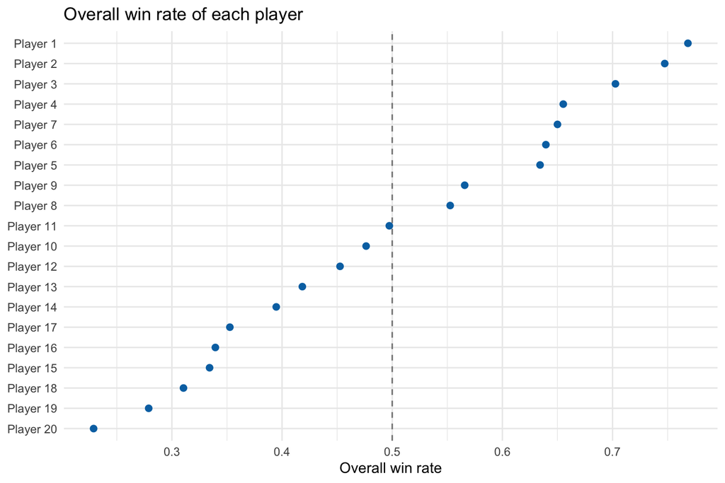

```r
ggplot(player_table, aes(x = win_rate, y = reorder(item, win_rate))) +
  geom_point(colour = "#0072B2", size = 2) +
  geom_vline(xintercept = 0.5, linetype = "dashed", colour = "grey50") +
  labs(x = "Overall win rate", y = NULL,
       title = "Overall win rate of each player") +
  theme_minimal()
```

Win rates provide a descriptive ordering before any model is fitted. Here the generating strengths are individual values, so we do not interpret gaps as evidence of generating blocks.

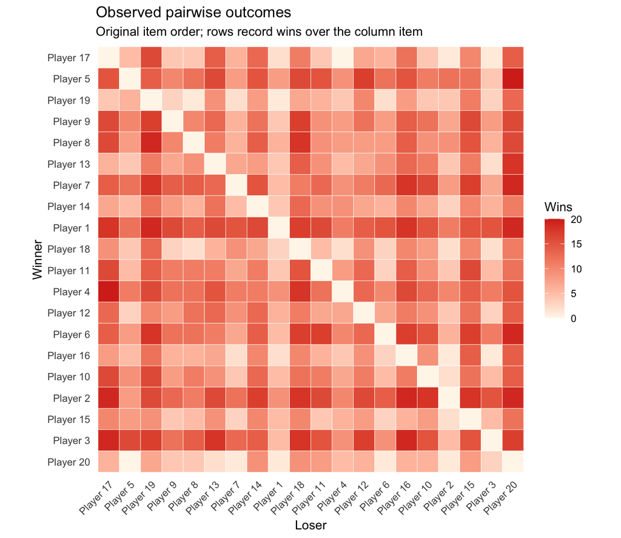

```r
plot_pairwise_outcomes(tennis, reorder = FALSE)
```

With `reorder = FALSE`, both axes retain the input item order.

This illustrates R’s S3 object-oriented interface. `tennis` has class `btsbm_pairwise_data`. The generic `plot_pairwise_outcomes()` selects its method for that class. A class identifies a kind of object; its methods implement operations on that kind of object. The corresponding BT-fit method extracts the observed data from a fitted model. Both methods plot observed counts, not fitted probabilities.

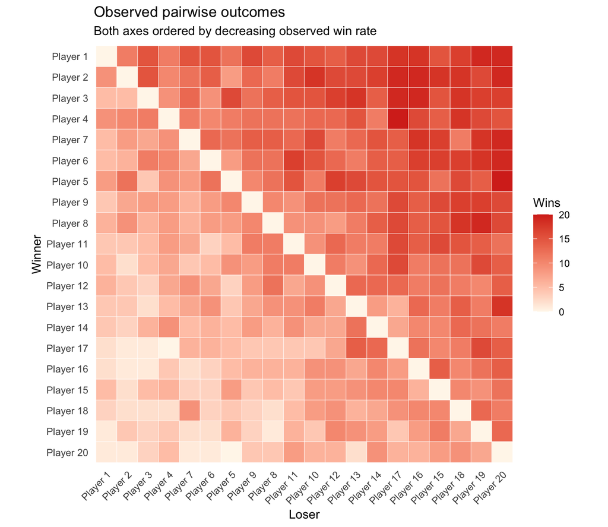

```r
plot_pairwise_outcomes(tennis, reorder = TRUE)
```

With `reorder = TRUE`, both axes are sorted by decreasing observed overall win rate. This uses the observations alone; it does not estimate model strengths or a partition.

## 2.3 The standard Bradley–Terry model

Each player gets their own strength $\lambda_i$ with an independent Gamma prior. We specify only `shape_lambda`; the constructor supplies the common rate automatically; omitting its argument does not remove the rate from the Gamma distribution.

```r
bt_fit <- fit_model(
  tennis,
  bt_model(shape_lambda = 2),
  mcmc_control(iter = 4000, warmup = 2000, seed = 12)
)
bt_fit
```

```
## <btsbm_fit> Bradley-Terry (BT), one strength per item
##   20 items; 2000 retained posterior draws. Use summary() for results.
```

```r
summary(bt_fit)
```

```
## Model:   Bradley-Terry (BT), one strength per item
## Data:    20 items, 190 compared pairs, 3800 comparisons
## Priors:  lambda_i ~ iid Gamma(shape_lambda = 2, rate_lambda = 1.526)
## MCMC:    4000 iterations, 2000 warm-up, 2000 retained draws (3.0 s)
##
## Relative strengths (arithmetic mean = 1), 90% credible intervals:
##       item  mean median lower upper
##   Player 1 2.611  2.600 2.158 3.112
##   Player 2 2.361  2.355 1.965 2.804
##   Player 3 1.899  1.894 1.578 2.256
##   Player 4 1.522  1.518 1.282 1.792
##   Player 7 1.498  1.483 1.247 1.797
##   Player 6 1.437  1.428 1.195 1.706
##   Player 5 1.400  1.395 1.179 1.646
##   Player 9 1.040  1.036 0.871 1.221
##   Player 8 0.986  0.976 0.832 1.175
##  Player 11 0.778  0.773 0.652 0.927
##   ... 10 more items; see strength_summary().
```

`iter` counts all iterations; `warmup` specifies the **burn-in** to discard. Thus this run retains 2,000 of its 4,000 iterations. The R argument is still called `warmup`, and the package’s printed summary calls it warm-up.

### 2.3.1 Relative strengths

The likelihood identifies strength ratios: multiplying every $\lambda_i$ by the same positive constant changes no win probability. A proper Gamma prior supplies the posterior raw scale, which the likelihood itself does not identify.

For retained draw $s$, let $\bar\lambda^{(s)}=n^{-1}\sum_{j=1}^{n}\lambda_j^{(s)}$ be the arithmetic mean strength across the $n$ players. The package reports
$$\theta_i^{(s)}=\frac{\lambda_i^{(s)}}{\bar\lambda^{(s)}},
\qquad \frac{1}{n}\sum_{i=1}^{n}\theta_i^{(s)}=1.$$
Thus a strength of 2 means twice the mean player strength in that draw. The independent Gamma priors remain on the raw $\lambda_i$; the derived $\theta_i$ have a fixed mean and are not independent Gamma variables. For comparison with the earlier sum-to-one shares, $\theta_i^{(s)}=nq_i^{(s)}$. If $S$ is the number of retained draws, the plotted dot is $S^{-1}\sum_{s=1}^{S}\theta_i^{(s)}$, estimating $E(\theta_i\mid y)$. Normalise **each draw before averaging**; this is generally different from normalising the vector of raw posterior means. Posterior mean relative strengths also have arithmetic mean one across players. The dashed line at 1 marks this reference, not each player’s posterior mean.

The BT likelihood is unchanged, since
$$\frac{\lambda_i}{\lambda_i+\lambda_j}
=\frac{\theta_i}{\theta_i+\theta_j}.$$

A hypothetical reference player with strength $\lambda_\star^{(s)}=\bar\lambda^{(s)}$ gives a useful interpretation in each draw:
$$p_{i\star}^{(s)}=\frac{\theta_i^{(s)}}{1+\theta_i^{(s)}},
\qquad \theta_i^{(s)}=\frac{p_{i\star}^{(s)}}{1-p_{i\star}^{(s)}}.$$
The relative strength is exactly the odds of beating that reference player. This is not the probability of beating a randomly chosen actual opponent.

| Sum-to-one share $q_i$ ($n=20$) | Relative strength $\theta_i$ | Interpretation | $p_{i\star}$ |
| --- | --- | --- | --- |
| 0.0125 | 0.25 | Quarter of the mean strength | 20% |
| 0.0250 | 0.50 | Half the mean strength | 33.3% |
| 0.0500 | 1.00 | Mean strength | 50% |
| 0.1000 | 2.00 | Twice the mean strength | 66.7% |
| 0.2000 | 4.00 | Four times the mean strength | 80% |

These identities hold **draw by draw**. A posterior predictive probability against this reference is $S^{-1}\sum_s p_{i\star}^{(s)}$; generally it is not $E(\theta_i\mid y)/(1+E(\theta_i\mid y))$. Similarly, the posterior mean strength is not the odds of that averaged probability. Use `posterior_strength(fit, scale = "share")` for the earlier sum-to-one convention, or `scale = "raw"` for the strengths as stored by the sampler.

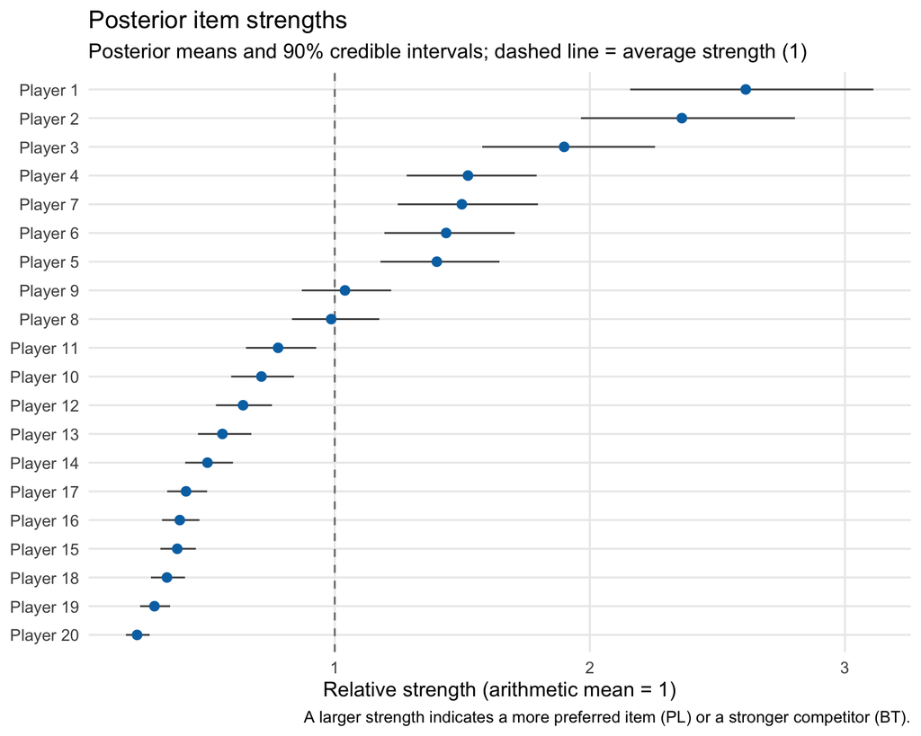

```r
bt_strength <- strength_summary(bt_fit)
plot_strength_summary(bt_fit)
```

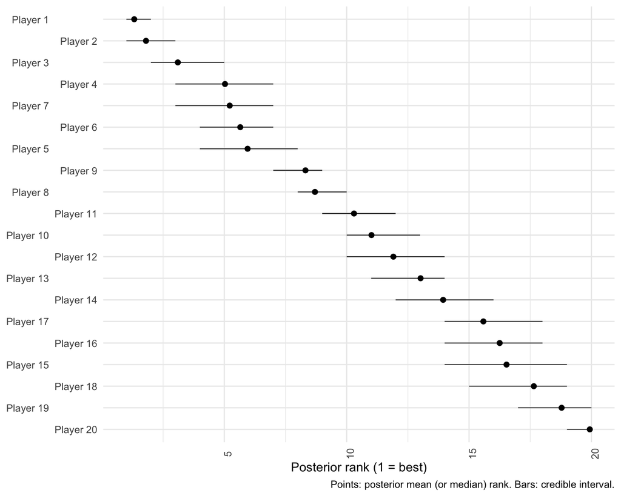

```r
plot_rank_intervals(bt_fit)
```

Rank 1 is strongest. The rank plot uses 95% central intervals by default; `plot_strength_summary()` above uses 90%. In a block model tied strengths receive average ranks (midranks).

### 2.3.2 Who is stronger than whom? $\Pr(\lambda_i > \lambda_j \mid y)$

Rankings hide how sure we are about each comparison. `prob_stronger()` returns, for every pair, the posterior probability that the row player is stronger than the column player.

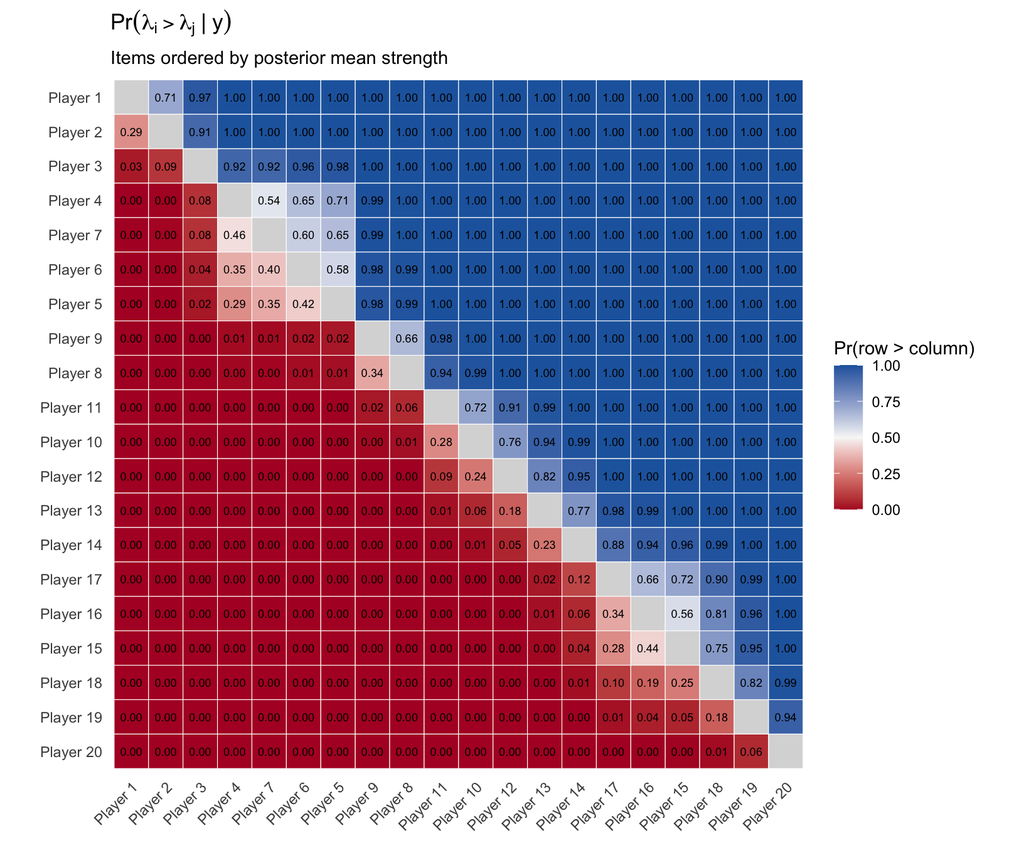

```r
plot_prob_stronger(bt_fit)
```

The colour scale is centred at 0.5. White indicates little posterior preference for either strength ordering. Under the standard BT model, exact strength ties have posterior probability zero. Sampling variation still makes the ordering uncertain.

This is a probability of **strength ordering**, not a posterior predictive win probability. The latter averages $\lambda_i/(\lambda_i+\lambda_j)$ over the posterior draws.

### 2.3.3 Checking the MCMC

Convergence checks use the relative strengths with arithmetic mean one. Exported columns are named after the players, such as `rel_strength[Player 1]`.

```r
top_players <- strength_summary(bt_fit) |>
  slice_head(n = 4) |>                       # Four largest posterior means.
  transmute(parameter = paste0("rel_strength[", item, "]")) |>
  pull(parameter)                            # Names used by coda/bayesplot.
chain <- coda::as.mcmc(bt_fit)
round(coda::effectiveSize(chain)[top_players])
```

```
## rel_strength[Player 1] rel_strength[Player 2] rel_strength[Player 3]
##                    300                    303                    343
## rel_strength[Player 4]
##                    446
```

ESS is interpreted relative to the 2000 retained draws. Autocorrelation reduces information; inspect traces too. The bayesplot appendix gives trace and interval examples.

A single chain cannot reveal every problem. Run a second, independent chain with a different seed and compare:

```r
bt_fit2 <- fit_model(tennis, bt_fit$model,
                     mcmc_control(iter = 4000, warmup = 2000, seed = 112))
chains <- as_mcmc_chains(list(bt_fit, bt_fit2))
coda::gelman.diag(chains[, top_players], autoburnin = FALSE, multivariate = FALSE)
```

```
## Potential scale reduction factors:
##
##                        Point est. Upper C.I.
## rel_strength[Player 1]          1       1.00
## rel_strength[Player 2]          1       1.00
## rel_strength[Player 3]          1       1.00
## rel_strength[Player 4]          1       1.01
```

Values of the potential scale reduction factor close to 1 are reassuring, but are not proof of convergence. `autoburnin = FALSE` prevents coda from discarding a second burn-in. We use `multivariate = FALSE` because the full vector of relative strengths sums to $n$ in every draw and has singular covariance. These short teaching runs need longer, independently checked chains for a substantive analysis.

# 3 BT–SBM practical: shared block strengths

The BT–SBM introduces the following quantities:

| Symbol | Meaning |
| --- | --- |
| $K$ | number of occupied item blocks |
| $x_i \in \{1,\ldots,K\}$ | block membership of player $i$ |
| $\lambda_k > 0$ | strength shared by players in block $k$ |
| $\theta_i=\lambda_{x_i}/\bar\lambda$ | relative strength of player $i$ |

Here $\bar\lambda=n^{-1}\sum_{j=1}^{n}\lambda_{x_j}$. The mean is over players, so blocks are weighted by their sizes; it is not the unweighted mean of the $K$ block strengths.

Given the partition, occupied-block strengths have independent Gamma priors with shape `shape_lambda` and the package-default rate. The partition $x$ receives a prior under which $K$ is random. The win probability is $\theta_i/(\theta_i+\theta_j)$, so same-block players beat each other with probability 1/2. Block membership does not depend on the numerical labels used to encode the partition.

## 3.1 Generate a block-model example

We now create a **new** dataset whose players share strengths within generating blocks. This comes after the BT–SBM theory session and its notation above.

```r
edges_sbm <- simulate_data(
  model = "bt-sbm",
  n_blocks = 4, latent_strength = c(12, 6, 2, 1), # One strength per block.
  players_per_block = 5, # Unequal sizes are also allowed: c(3, 4, 5, 8).
  matches_per_pair = 20, seed = 101, format = "edgelist"
)
tennis_sbm <- as_bt_data(edges_sbm, format = "edgelist")
truth <- attr(edges_sbm, "truth")
edges_sbm |> slice_head(n = 6) |> knitr::kable()
```

| winner | loser | count |
| --- | --- | --- |
| Isla Kent | Tara Fox | 8 |
| Isla Kent | Will Gray | 6 |
| Isla Kent | Jack Ford | 3 |
| Isla Kent | Rosa Hill | 12 |
| Isla Kent | Maya Cole | 11 |
| Isla Kent | Leo Wood | 6 |

`model = "bt-sbm"` interprets `latent_strength` as one positive value per block. A scalar `players_per_block = 5` gives five players in every block. Unequal sizes are allowed: `players_per_block = c(3, 4, 5, 8)` gives those four sizes, with twenty players in total. If omitted, `n_blocks` is inferred from the number of generating strengths. The function randomly assigns memberships to player names subject to these sizes, then simulates all pair counts using the implied raw player strengths $\lambda_{x_i}$. Reporting then divides by their arithmetic mean to obtain $\theta_i$.

The `truth` attribute records the generating blocks and strengths. We use it to assess recovery; it is not supplied to `fit_model()`.

### 3.1.1 Prior on the number of blocks

Before seeing data, how many blocks does each partition prior expect among $n = 20$ players?

```r
priors <- list(
  Gnedin = gnedin_prior(gnedin_hyper = 0.5),
  DP = dirichlet_process_prior(concentration = 1),
  PitmanYor = pitman_yor_prior(concentration = 1, discount = 0.2),
  DirMult_max4 = dirichlet_multinomial_prior(max_clusters = 4, concentration = 1)
)
tibble(
  prior = names(priors),
  mean_K = vapply(priors, function(p) prior_mean_K(20, p), numeric(1)),
  sd_K = sqrt(vapply(priors, function(p) prior_variance_K(20, p), numeric(1)))
) |> knitr::kable(digits = 2) # NA: variance not implemented for PY/DM.
```

| prior | mean_K | sd_K |
| --- | --- | --- |
| Gnedin | 3.99 | 5.10 |
| DP | 3.60 | 1.41 |
| PitmanYor | 4.97 | NA |
| DirMult_max4 | 3.48 | NA |

For fixed $n$, $K$ is always at most $n$. The Gnedin prior also allows a random, almost surely finite limiting number of blocks as the number of items grows; it has no fixed upper bound. With the chosen hyperparameter, its prior mean and standard deviation for $n=20$ are about 3.99 and 5.10. A wide prior is still informative: examine sensitivity to its hyperparameter. For the Dirichlet–multinomial, `max_clusters = 4` fixes an upper bound, and `concentration = 1` is the symmetric concentration **per** possible block. The DP and Pitman–Yor priors have no fixed finite bound as $n$ grows.

### 3.1.2 Exercise: partition hyperparameters

Let $K_n$ be the number of occupied groups among $n=20$ items before seeing outcomes. Simulate under Gnedin gamma 0.5 and DP concentration 1.2. Their exact means are almost equal (3.988 and 3.983), so comparing their shapes and upper tails is informative. Then change either hyperparameter and repeat.

```r
prior_n <- 20L                             # Number of items, before observing outcomes.
prior_B <- 50000L                          # Independent simulations per prior.
prior_comparison <- list(
  Gnedin = gnedin_prior(gnedin_hyper = 0.5),
  DP = dirichlet_process_prior(concentration = 1.2)) # Nearly equal expected K.
prior_draws <- bind_rows(lapply(seq_along(prior_comparison), function(i) {
  tibble(prior = names(prior_comparison)[i],
    K = prior_sample_K(prior_n, prior_comparison[[i]],
                       draws = prior_B, seed = 30 + i))
})) |> mutate(prior = factor(prior, levels = names(prior_comparison)))
prior_expectation <- tibble(
  prior = factor(names(prior_comparison), levels = names(prior_comparison)),
  expected_K = vapply(prior_comparison,
    function(p) prior_mean_K(prior_n, p), numeric(1))) # Exact, not a sample mean.
```

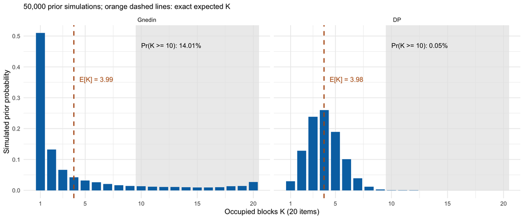

```r
prior_mass <- prior_draws |>
  count(prior, K, name = "draws") |>          # Counts across independent simulations.
  complete(prior, K = seq_len(prior_n), fill = list(draws = 0L)) |>
  mutate(probability = draws / prior_B,      # Keep the complete finite support.
         prior = factor(prior, levels = names(prior_comparison)))
prior_tails <- prior_draws |>
  group_by(prior) |>
  summarise(tail_probability = mean(K >= 10), .groups = "drop") |>
  mutate(label = sprintf("Pr(K >= 10): %.2f%%", 100 * tail_probability))
ggplot(prior_mass, aes(K, probability)) +
  annotate("rect", xmin = 9.5, xmax = prior_n + 0.5,
           ymin = 0, ymax = Inf, fill = "grey90", alpha = 0.7) + # Upper tail.
  geom_col(fill = "#0072B2", width = 0.8) +
  geom_vline(data = prior_expectation, aes(xintercept = expected_K),
             colour = "#b35806", linetype = "dashed", linewidth = 0.8) +
  geom_text(data = prior_expectation,
    aes(x = expected_K + 0.5, y = 0.36, label = sprintf("E[K] = %.2f", expected_K)),
    inherit.aes = FALSE, hjust = 0, colour = "#b35806", size = 3.6) +
  geom_text(data = prior_tails, aes(x = 10, y = 0.47, label = label),
             inherit.aes = FALSE, hjust = 0, size = 3.5) +
  facet_wrap(~ prior, nrow = 1) +             # Identical axes in both panels.
  scale_x_continuous(breaks = c(1, 5, 10, 15, 20), limits = c(0.5, prior_n + 0.5)) +
  labs(x = paste0("Occupied blocks K (", prior_n, " items)"),
       y = "Simulated prior probability",
       subtitle = paste(format(prior_B, big.mark = ","),
         "prior simulations; orange dashed lines: exact expected K")) +
  theme_minimal()
```

Each panel contains 50,000 independent prior simulations. Orange dashed lines mark exact expectations from `prior_mean_K()`, rather than the sample means. The grey region is $K_n\ge10$; its estimated probability is printed in each panel. Gnedin assigns substantially more probability to large occupied counts in this example, despite the similar expectations. Both distributions are bounded by twenty: this is a comparison of their finite-sample upper tails. See [Gnedin (2010)](https://doi.org/10.1214/ECP.v15-1532) for the predictive allocation rules and the distinction from the limiting number of types.

### 3.1.3 Fit

```r
sbm_model <- bt_sbm_model(
  shape_lambda = 2,
  item_clustering = gnedin_prior(gnedin_hyper = 0.5)
)
sbm_model
```

```
## <btsbm_model> Bradley-Terry stochastic block model (BT-SBM), items share block strengths
##   strength prior:   lambda_k ~ iid Gamma(shape_lambda = 2, rate_lambda = 1.526)
##   item partition:    x ~ Gnedin(gnedin_hyper = 0.5)
```

```r
sbm_fit <- fit_model(tennis_sbm, sbm_model,
                     mcmc_control(iter = 10000, warmup = 5000, seed = 2))
summary(sbm_fit)
```

```
## Model:   Bradley-Terry stochastic block model (BT-SBM), items share block strengths
## Data:    20 items, 190 compared pairs, 3800 comparisons
## Priors:  lambda_k ~ iid Gamma(shape_lambda = 2, rate_lambda = 1.526)
##          item partition x ~ Gnedin(gnedin_hyper = 0.5)
## MCMC:    10000 iterations, 5000 warm-up, 5000 retained draws (7.1 s)
##
## Posterior number of blocks, Pr(K = k | y):
##     4     5     6     7     8     9    10
## 0.583 0.271 0.099 0.032 0.011 0.004 0.001
##
## Point estimate of the partition (block 1 = strongest):
##   Block 1 (5 items): Jack Ford, Leo Wood, Dan Moss, Kira Lane, Noah Bell
##   Block 2 (5 items): Tara Fox, Rosa Hill, Orla Hart, Paul Snow, Alex Vale
##   Block 3 (5 items): Isla Kent, Will Gray, Maya Cole, Hugo Dale, Ben Holt
##   Block 4 (5 items): Ella Shaw, Finn Lake, Sam Ward, Cara Reed, Gina West
```

`summary()` reports the number of blocks and an estimated partition for a block model. Player-level implied strengths remain well defined, so `strength_summary(sbm_fit)` and `as.matrix(sbm_fit)` are also available; they do not require matching arbitrary block labels between draws.

### 3.1.4 How many blocks?

```r
posterior_K_table(sbm_fit)
```

| K | draws | probability |
| --- | --- | --- |
| 4 | 2915 | 0.5830 |
| 5 | 1357 | 0.2714 |
| 6 | 496 | 0.0992 |
| 7 | 158 | 0.0316 |
| 8 | 53 | 0.0106 |
| 9 | 18 | 0.0036 |
| 10 | 3 | 0.0006 |

The generating value is $K=4$. It receives 58.3% of the retained draws, while 41.7% have more than four blocks. These are Monte Carlo estimates under the specified likelihood and priors.

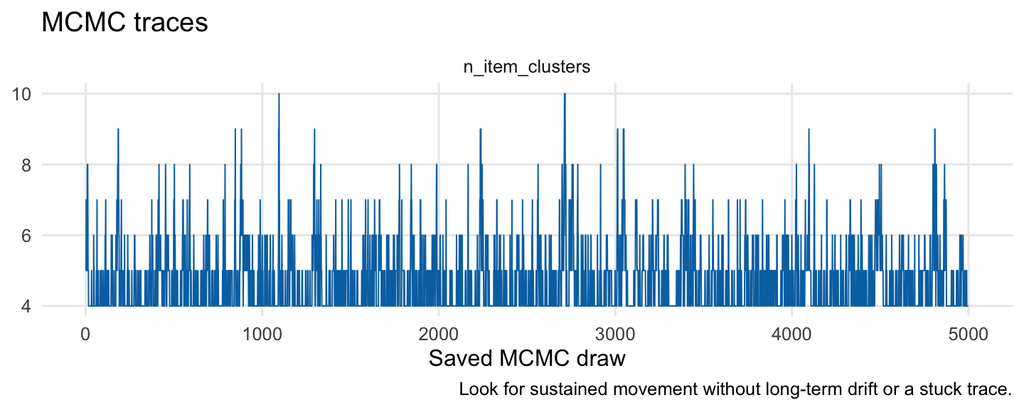

```r
plot_mcmc_traces(sbm_fit)
```

### 3.1.5 The estimated partition and the reordered data

`partition_point_estimate()` searches for a partition with low posterior expected variation of information (VI) loss. It uses `salso` when installed, otherwise a built-in candidate search; neither guarantees a global minimum. The built-in VI search evaluates a shortlist against at most 1,000 evenly spaced retained draws. The centre may therefore depend on the search method. Blocks are labelled in decreasing order of the average posterior mean normalised player strength within the estimated block. Compare with the truth:

```r
set.seed(100)                               # Reproduce the partition search.
x_hat <- partition_point_estimate(sbm_fit)
tibble(item = names(x_hat), estimated_block = unname(x_hat)) |>
  left_join(truth, by = "item") |>            # Match players by name.
  count(estimated_block, true_block) |>       # Count the overlap of blocks.
  pivot_wider(names_from = true_block, values_from = n, values_fill = 0) |>
  knitr::kable()                             # Display a cross-tabulation.
```

| estimated_block | 1 | 2 | 3 | 4 |
| --- | --- | --- | --- | --- |
| 1 | 5 | 0 | 0 | 0 |
| 2 | 0 | 5 | 0 | 0 |
| 3 | 0 | 0 | 5 | 0 |
| 4 | 0 | 0 | 0 | 5 |

Now redraw the outcome matrix with players ordered by their estimated block:

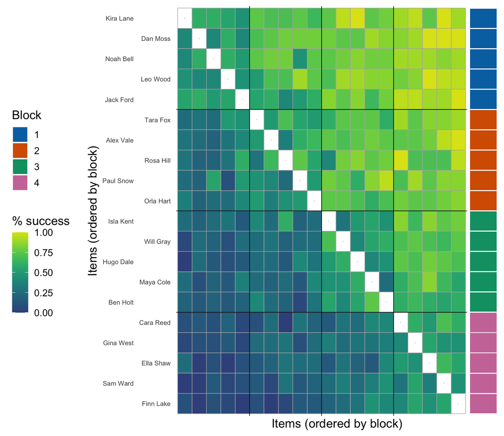

```r
plot_ordered_adjacency(sbm_fit, x_hat, clean_fun = NULL)
```

This plot uses the new BT–SBM dataset and orders its observations by the estimated partition. That ordering uses a fitted model, unlike the observed win-rate ordering used in the BT practical.

### 3.1.6 Membership probabilities

`plot_assignment_probabilities()` shows, for each player, the posterior probability of belonging to each block, **conditional on a given number of blocks** $K$. In each retained draw the function relabels blocks in decreasing strength order, so column 1 means the strongest block in that draw, not an unchanging group of players. This ordering is needed even when $K$ is fixed. The colour scale is centred at 0.5: blue means “more likely than not”.

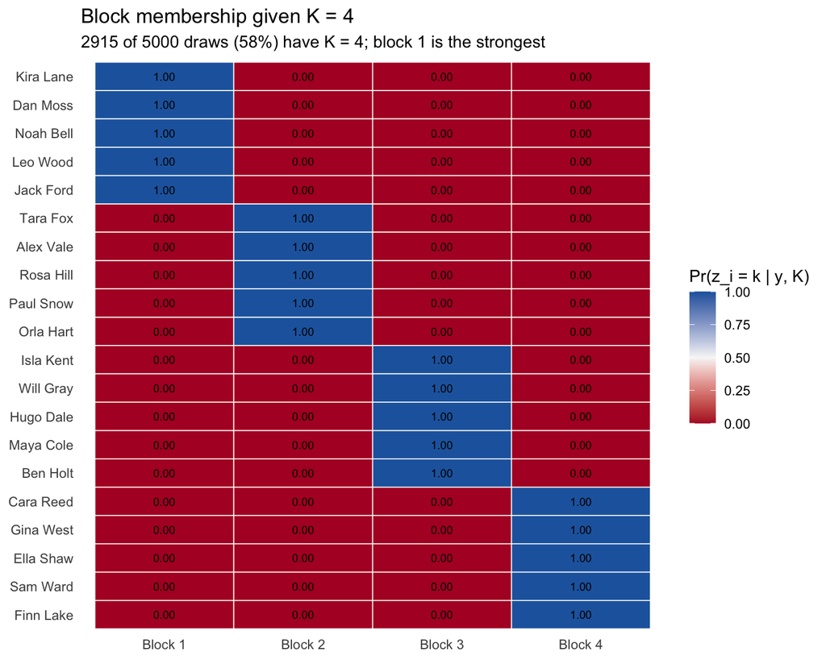

```r
plot_assignment_probabilities(sbm_fit, k_show = 4, clean_fun = NULL)
```

```r
true_tier <- truth$true_block[match(tennis_sbm$item_labels, truth$item)] # Align items.
true_pairs <- outer(true_tier, true_tier, `==`) # Label-invariant truth.
recovers_truth <- apply(sbm_fit$draws$item_cluster, 1, function(x) {
  all(outer(x, x, `==`) == true_pairs)          # Compare co-memberships.
})
recovery_given_K4 <- mean(recovers_truth[sbm_fit$draws$n_item_clusters == 4])
```

Among the 2915 retained draws with $K=4$, 100% reproduce the generating partition. This does **not** imply posterior certainty: the 41.7% of draws with a different $K$ are excluded. Nor does a sampled frequency of zero establish zero posterior probability. Now inspect draws with five blocks:

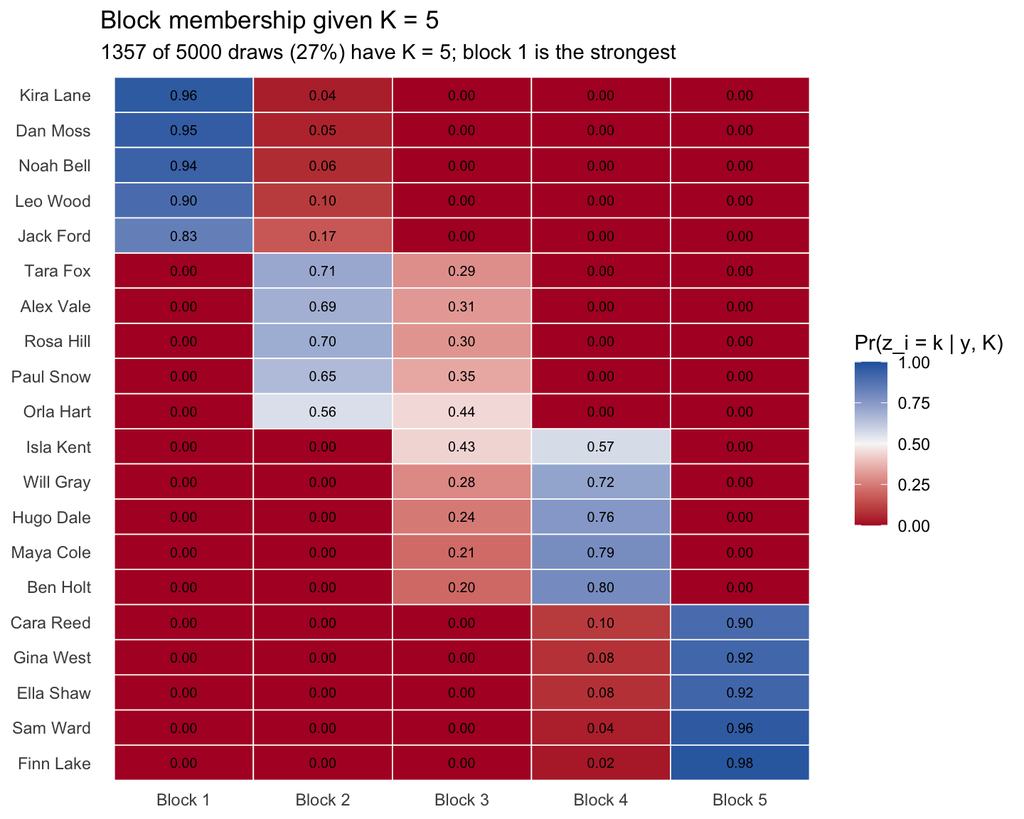

```r
plot_assignment_probabilities(sbm_fit, k_show = 5, clean_fun = NULL)
```

In this run the five-block draws split one generating tier into two sub-blocks. Since columns refer to strength order, splitting a strong tier can shift the column labels of weaker, otherwise unchanged tiers. Intermediate cells can therefore reflect both splitting and changes in block order; the label-invariant summaries below separate these effects.

### 3.1.7 Which players belong together?

The full co-clustering matrix averages over every retained draw, including all observed values of K. No K condition or probability threshold is applied. Four decimal places retain the resolution of these 5,000 retained draws.

The posterior similarity matrix does not condition on $K$: cell $(i, j)$ is $\Pr(x_i = x_j \mid y)$, the proportion of all draws in which the two players share a block. Outlines show the estimated partition.

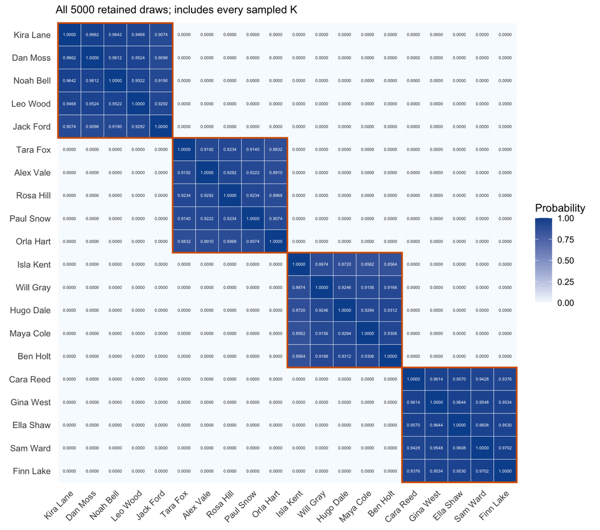

```r
similarity <- posterior_similarity(sbm_fit, target = "item") # All retained draws.
set.seed(100)                               # Reproduce the block outlines.
plot_posterior_similarity(sbm_fit, show_values = TRUE, digits = 4) +
  labs(title = NULL, subtitle = paste("All", nrow(sbm_fit$draws$item_cluster),
       "retained draws; includes every sampled K"))
```

```r
within_estimate <- outer(x_hat, x_hat, `==`) # Pairs in the same estimated block.
within_similarity <- range(similarity[within_estimate & row(similarity) != col(similarity)])
outside_similarity <- range(similarity[!within_estimate]) # Between-block pairs.
```

Off-diagonal co-clustering frequencies within estimated blocks range from 0.856 to 0.97; between estimated blocks they range from 0 to 0. `block_stability()` checks whether separation comes from splitting a block, merging with outside players, or both:

```r
sbm_stability <- block_stability(sbm_fit, x_hat)
sbm_stability |>
  select(block, size, together, split, merged) |> # Retain interpretable summaries.
  knitr::kable(digits = 3)
```

| block | size | together | split | merged |
| --- | --- | --- | --- | --- |
| 1 | 5 | 0.882 | 0.118 | 0 |
| 2 | 5 | 0.826 | 0.174 | 0 |
| 3 | 5 | 0.808 | 0.192 | 0 |
| 4 | 5 | 0.913 | 0.087 | 0 |

The largest sampled `merged` frequency is 0. In this run no retained draw joins players from different estimated blocks; the observed uncertainty concerns splits. This is a property of these draws, not a proof that posterior merging probability is zero.

`together` means the whole estimated block is reproduced exactly: all its players are together and no outside player joins. `split` and `merged` can both occur in one draw, so the three columns need not sum to one.

### 3.1.8 Credible ball for the partition

Following [Wade and Ghahramani (2018)](https://doi.org/10.1214/17-BA1073), we choose the smallest VI radius around the estimated partition $\hat x$ that contains **at least** 95% of retained draws. Distances use base-2 logarithms. The native method selects representative bounds **among sampled partitions inside the ball**, rather than searching all possible partitions: the upper/lower vertical bounds have the fewest/most blocks, breaking ties by greatest VI distance from $\hat x$; the horizontal bound is furthest away. These are not a central credible interval for $K$.

```r
cb <- credible_ball(sbm_fit, x_hat, credible_mass = 0.95)
cb
```

```
## <credible ball for the item partition x>
##   95% ball, VI radius 0.485 (contains 95.5% of draws; method: native)
##   Number of blocks K:
##     point estimate        4
##     upper vertical bound  4  (coarsest partition in the ball)
##     lower vertical bound  7  (finest partition in the ball)
##     horizontal bound      6  (furthest partition from the estimate)
```

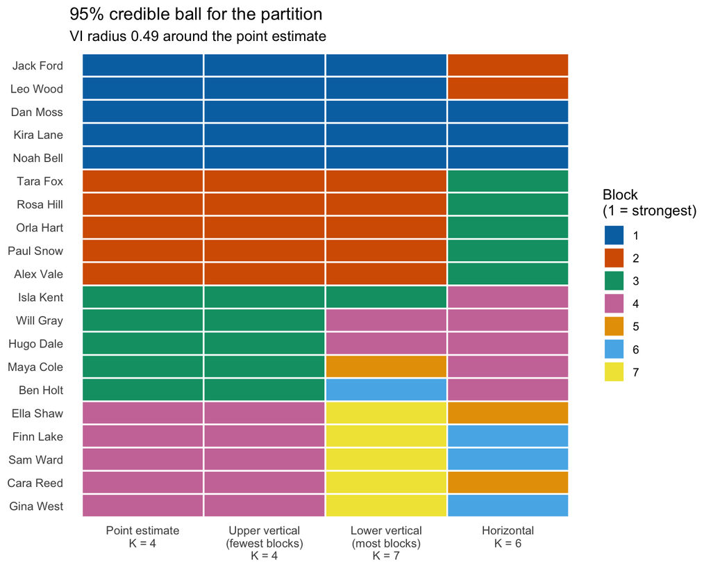

```r
plot_credible_ball(cb)
```

If the GitHub package `mcclust.ext` is installed, `credible_ball(sbm_fit, x_hat, method = "mcclust.ext")` provides a cross-check using the reference implementation. Search and tie handling can give different representative bounds; exact equality is not guaranteed.

### 3.1.9 Exercise: closer generating strengths

Replace c(12, 6, 2, 1) by c(12, 9, 2, 1). Compare Pr(K = 4 | y) and the 95% VI-ball radius with the original fit.

The exercise uses distinct object names to preserve the main fit. Run it when it is introduced during the session.

```r
closer_data <- simulate_data("bt-sbm", latent_strength = c(12, 9, 2, 1),
  players_per_block = 5, matches_per_pair = 20, seed = 101)
closer_fit <- fit_model(closer_data, sbm_model, sbm_fit$control) # Same prior and MCMC.
set.seed(100)                               # Reproduce the partition search.
closer_x_hat <- partition_point_estimate(closer_fit)
closer_ball <- credible_ball(closer_fit, closer_x_hat)
```

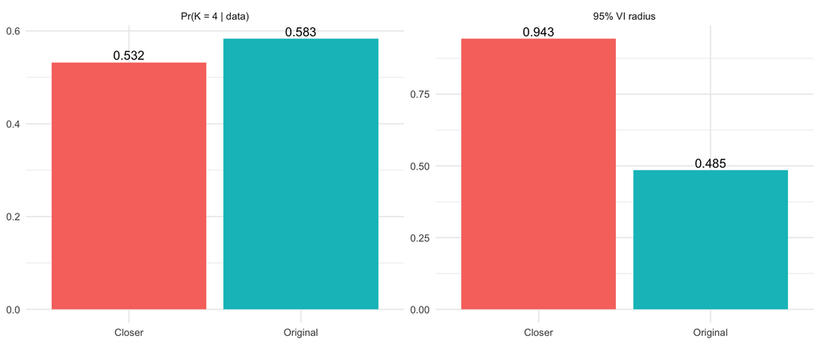

```r
signal_comparison <- tibble(
  data = c("Original", "Closer"),
  Pr_K4 = c(mean(sbm_fit$draws$n_item_clusters == 4),
            mean(closer_fit$draws$n_item_clusters == 4)),
  VI_radius = c(cb$radius, closer_ball$radius)
) |> pivot_longer(-data, names_to = "summary", values_to = "value") # Plot both summaries.
ggplot(signal_comparison, aes(data, value, fill = data)) +
  geom_col() + geom_text(aes(label = round(value, 3)), vjust = -0.3) +
  facet_wrap(~ summary, scales = "free_y", nrow = 1,
    labeller = as_labeller(c(Pr_K4 = "Pr(K = 4 | data)", VI_radius = "95% VI radius"))) +
  labs(x = NULL, y = NULL) + theme_minimal() + theme(legend.position = "none")
```

### 3.1.10 $\Pr(\theta_i > \theta_j \mid y)$ in the block model

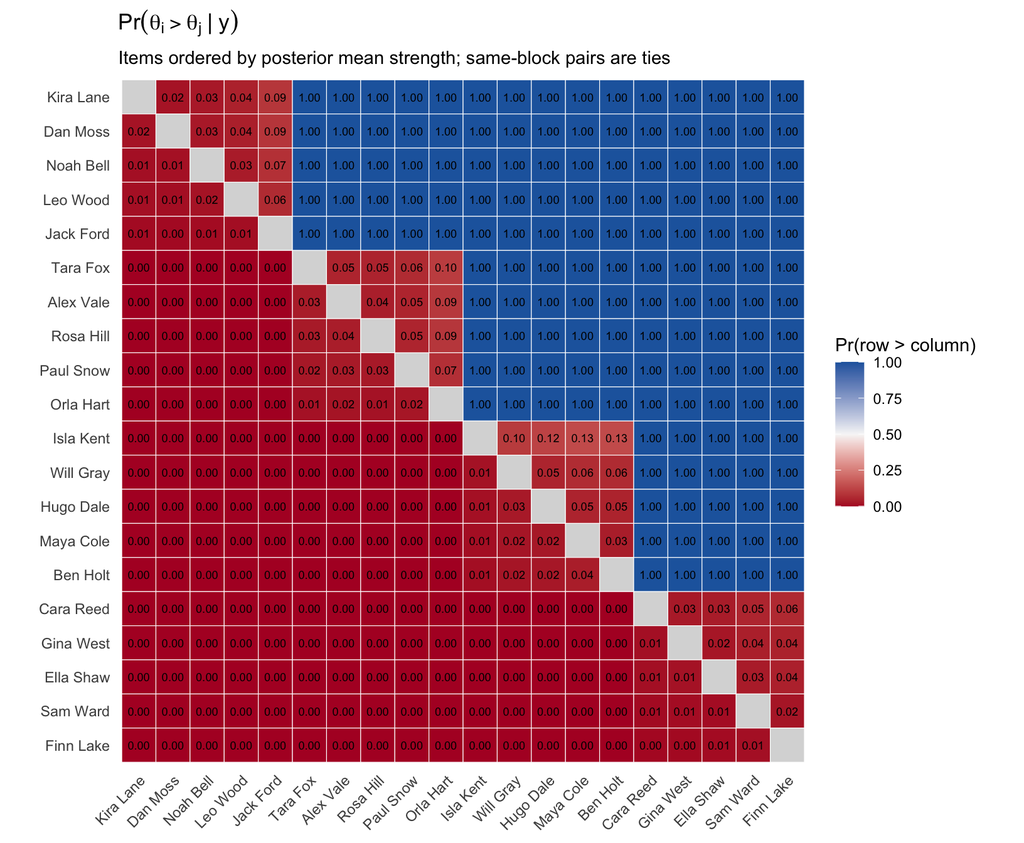

```r
plot_prob_stronger(sbm_fit) +
  labs(title = expression(Pr(theta[i] > theta[j] ~ "|" ~ y)))
```

Shared block strengths create exact ties. In this tiered dataset, players within a generating tier are usually *tied* ($\theta_i = \theta_j$), so both $\Pr(\theta_i > \theta_j \mid y)$ and $\Pr(\theta_j > \theta_i \mid y)$ can be small. A small value alone does not show that the row player is weaker: it can mean a tie. For distinct players, these two probabilities and $\Pr(\theta_i=\theta_j\mid y)$ sum to one. The tie probability is stored in the `prob_equal` attribute and equals the posterior similarity (apart from the deliberately blank diagonal):

```r
p_sbm <- prob_stronger(sbm_fit)
round(attr(p_sbm, "prob_equal")[1:5, 1:5], 2)
```

```
##           Kira Lane Dan Moss Noah Bell Leo Wood Jack Ford
## Kira Lane        NA     0.97      0.96     0.95      0.91
## Dan Moss       0.97       NA      0.96     0.95      0.91
## Noah Bell      0.96     0.96        NA     0.95      0.92
## Leo Wood       0.95     0.95      0.95       NA      0.93
## Jack Ford      0.91     0.91      0.92     0.93        NA
```

### 3.1.11 A second chain

```r
sbm_fit2 <- fit_model(tennis_sbm, sbm_model,
  mcmc_control(iter = 10000, warmup = 5000, seed = 202))
full_join(                                 # Align the supported values of K.
  posterior_K_table(sbm_fit) |> select(K, chain1 = probability),
  posterior_K_table(sbm_fit2) |> select(K, chain2 = probability), by = "K"
) |> knitr::kable(digits = 3)
```

| K | chain1 | chain2 |
| --- | --- | --- |
| 4 | 0.583 | 0.603 |
| 5 | 0.271 | 0.271 |
| 6 | 0.099 | 0.093 |
| 7 | 0.032 | 0.024 |
| 8 | 0.011 | 0.007 |
| 9 | 0.004 | 0.002 |
| 10 | 0.001 | 0.000 |
| 11 | NA | 0.000 |
| 12 | NA | 0.000 |

Similar block-count distributions in independent chains are one useful (but not sufficient) check of convergence.

# 4 Dataset 2: the 2017 ATP season

The package includes head-to-head counts for the 105 top ATP players in each season from 2000 to 2025.

## 4.1 Explore the data

```r
atp <- ATP_2000_2025[["2017"]]               # Select a season.
players <- atp$players_df
atp_data <- as_bt_data(atp$Y_ij, format = "matrix",
  item_labels = make.unique(players$player_label)) # Give each item a unique name.
atp_edges <- as_tibble(atp_data)             # Standard winner/loser/count table.
atp_data
```

```
## <btsbm_pairwise_data> 105 items and 1719 wins
```

```r
atp_pairs <- atp_edges |>
  group_by(first = pmin(winner, loser),    # Give each unordered pair one key.
           second = pmax(winner, loser)) |>
  summarise(matches = sum(count), .groups = "drop") # Sum both directions.
atp_overview <- tibble(
  players = atp_data$n_items, matches = sum(atp_edges$count),
  pairs_that_met = sum(atp_pairs$matches > 0), # Exclude unobserved pairs.
  possible_pairs = nrow(atp_pairs)
)
atp_overview |> knitr::kable()
```

| players | matches | pairs_that_met | possible_pairs |
| --- | --- | --- | --- |
| 105 | 1719 | 1363 | 5460 |

Unlike the synthetic league, most pairs never met: the data contain 1719 matches among 105 players, covering 25% of possible pairs. The model links comparisons through common opponents.

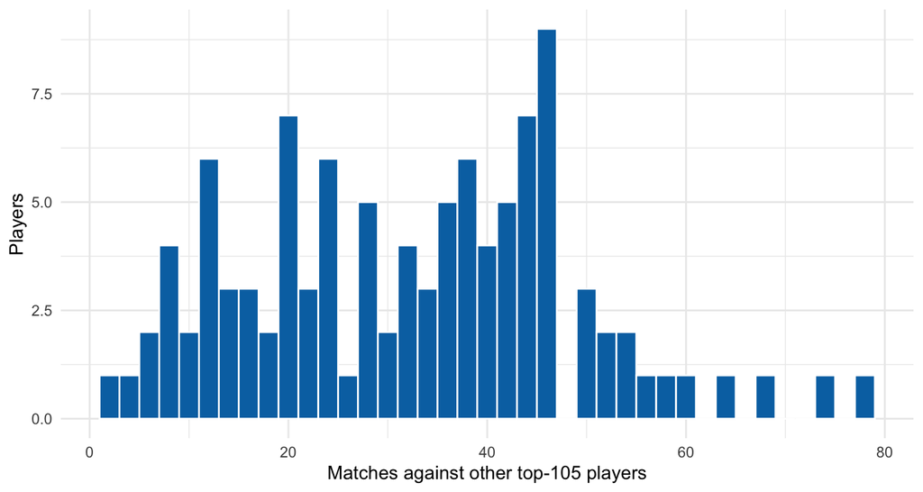

```r
atp_players <- pairwise_summary(atp_data) |> # Reuse the player-level summary.
  as_tibble() |>
  mutate(last_rank = players$last_rank)      # Metadata share the input item order.
ggplot(atp_players, aes(matches)) +
  geom_histogram(binwidth = 2, fill = "#0072B2", colour = "white") +
  labs(x = "Matches against other top-105 players", y = "Players") + theme_minimal()
```

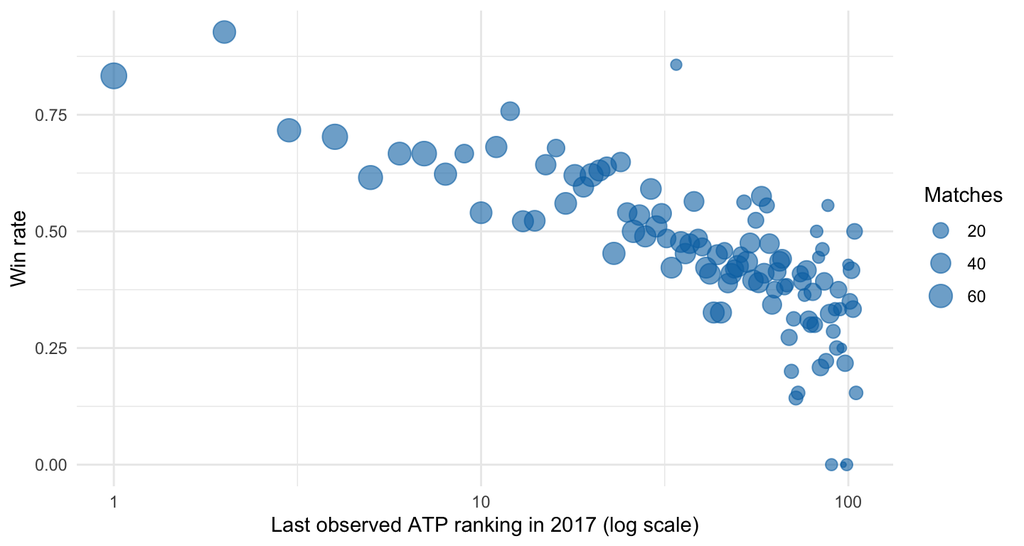

```r
ggplot(atp_players, aes(last_rank, win_rate)) +
  geom_point(aes(size = matches), alpha = 0.6, colour = "#0072B2") +
  scale_x_log10() +                          # ATP ranks span a wide range.
  labs(x = "Last observed ATP ranking in 2017 (log scale)", y = "Win rate", size = "Matches") +
  theme_minimal()
```

Win rate falls with ranking, but noisily, especially for players with few matches.

## 4.2 Fit the BT–SBM

```r
atp_fit <- fit_model(
  atp_data,
  bt_sbm_model(shape_lambda = 2,
               item_clustering = gnedin_prior(gnedin_hyper = 0.5)),
  mcmc_control(iter = 6000, warmup = 3000, seed = 1)
)
posterior_K_table(atp_fit)
```

| K | draws | probability |
| --- | --- | --- |
| 3 | 467 | 0.1556667 |
| 4 | 891 | 0.2970000 |
| 5 | 726 | 0.2420000 |
| 6 | 481 | 0.1603333 |
| 7 | 219 | 0.0730000 |
| 8 | 103 | 0.0343333 |
| 9 | 65 | 0.0216667 |
| 10 | 17 | 0.0056667 |
| 11 | 17 | 0.0056667 |
| 12 | 7 | 0.0023333 |
| 13 | 4 | 0.0013333 |
| 14 | 2 | 0.0006667 |
| 17 | 1 | 0.0003333 |

The number of tiers is much less certain than in the synthetic league.

### 4.2.1 Exercise: ATP prior sensitivity

Keep the 2017 data fixed. Compare Gnedin gamma = 0.5 with gamma = 0.8 and DP concentration = 1. Does the posterior mean of K follow the prior mean?

The exercise uses distinct object names to preserve the main fit. Run it when it is introduced during the session.

```r
atp_alternative_priors <- list(
  Gnedin_08 = gnedin_prior(gnedin_hyper = 0.8),
  DP_1 = dirichlet_process_prior(concentration = 1))
atp_alternative_fits <- lapply(atp_alternative_priors, function(prior) {
  fit_model(atp_data, bt_sbm_model(shape_lambda = 2, item_clustering = prior),
            atp_fit$control)                 # Change only the partition prior.
})
atp_prior_comparison <- c(list(Gnedin_05 = atp_fit), atp_alternative_fits) |>
  lapply(function(f) tibble(
    Prior = prior_mean_K(atp_data$n_items, f$model$item_clustering),
    Posterior = mean(f$draws$n_item_clusters))) |>
  bind_rows(.id = "prior")                   # Distinct names preserve the main fit.
```

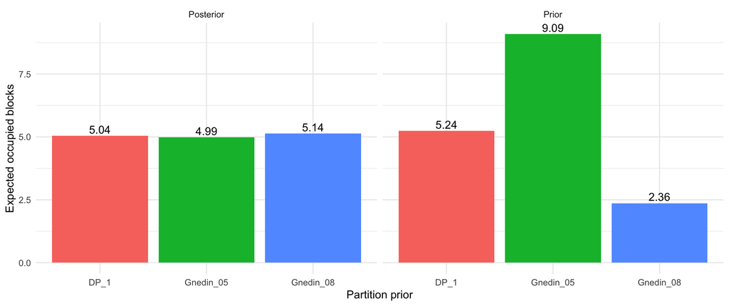

```r
atp_prior_comparison |>
  pivot_longer(c(Prior, Posterior), names_to = "distribution", values_to = "mean_K") |>
  ggplot(aes(prior, mean_K, fill = prior)) +
  geom_col() + geom_text(aes(label = round(mean_K, 2)), vjust = -0.3) +
  facet_wrap(~ distribution, nrow = 1) +      # Same K scale in both panels.
  labs(x = "Partition prior", y = "Expected occupied blocks") +
  theme_minimal() + theme(legend.position = "none")
```

### 4.2.2 The estimated tiers

```r
set.seed(200)  # Reproduce the partition search.
atp_x <- partition_point_estimate(atp_fit)
table(atp_x)
```

```
## atp_x
##  1  2  3
##  2 21 82
```

```r
names(atp_x)[atp_x == 1]          # the top tier
```

```
## [1] "Nadal R."   "Federer R."
```

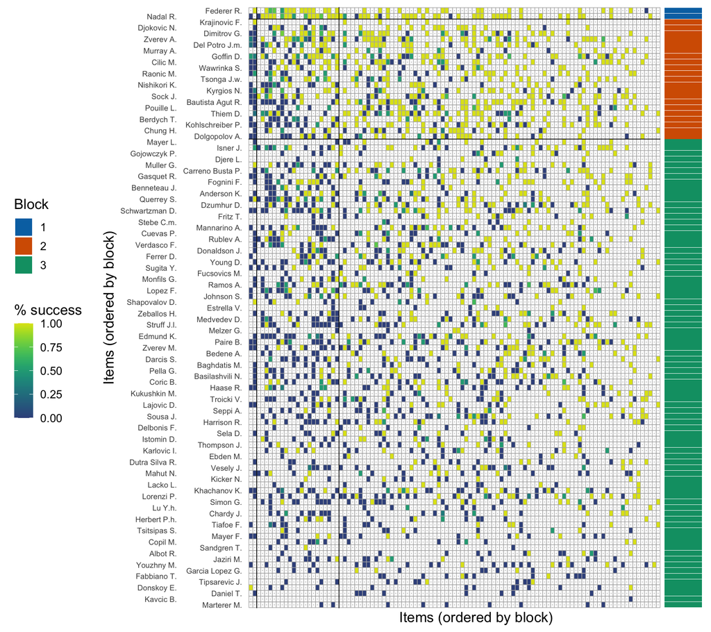

```r
plot_ordered_adjacency(atp_fit, atp_x, clean_fun = NULL)
```

Do the estimated tiers agree with the official rankings?

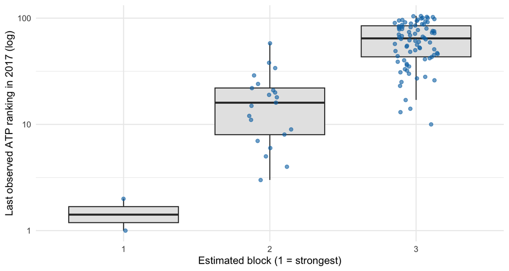

```r
set.seed(201)                               # Reproduce the horizontal jitter.
atp_players <- atp_players |>
  mutate(block = factor(atp_x[item]))        # Match block labels by item name.
ggplot(atp_players, aes(block, last_rank)) +
  geom_boxplot(outlier.shape = NA, fill = "grey90") +
  geom_jitter(width = 0.15, alpha = 0.6, colour = "#0072B2") +
  scale_y_log10() +
  labs(x = "Estimated block (1 = strongest)", y = "Last observed ATP ranking in 2017 (log)") +
  theme_minimal()
```

## 4.3 Uncertainty about the tiers

```r
atp_cb <- credible_ball(atp_fit, atp_x)
atp_cb
```

```
## <credible ball for the item partition x>
##   95% ball, VI radius 2.251 (contains 95.0% of draws; method: native)
##   Number of blocks K:
##     point estimate        3
##     upper vertical bound  3  (coarsest partition in the ball)
##     lower vertical bound  10  (finest partition in the ball)
##     horizontal bound      8  (furthest partition from the estimate)
```

```r
atp_stability <- block_stability(atp_fit, atp_x)
atp_stability |>
  select(block, size, together, split, merged) |> # Compare splitting and merging.
  knitr::kable(digits = 3)
```

| block | size | together | split | merged |
| --- | --- | --- | --- | --- |
| 1 | 2 | 0.483 | 0.033 | 0.513 |
| 2 | 21 | 0.000 | 0.959 | 1.000 |
| 3 | 82 | 0.000 | 0.999 | 1.000 |

The sampled bounds of this 95% VI ball have 3 to 10 blocks; this is not a 95% interval for $K$. The table reports how often each estimated block is reproduced, split or merged. The strongest estimated block is reproduced exactly in 48.3% of retained draws; it is split in 3.3% and merged with outside players in 51.3%. Exact recovery of a block is a stricter event than two specified players remaining together.

Membership probabilities for the most probable number of blocks:

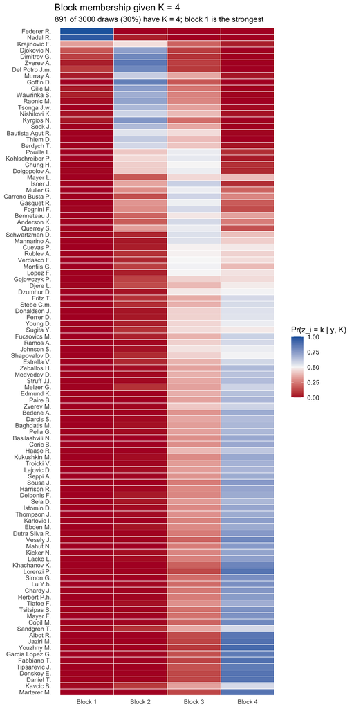

```r
plot_assignment_probabilities(atp_fit, clean_fun = NULL)
```

## 4.4 Who is stronger than whom among the top players?

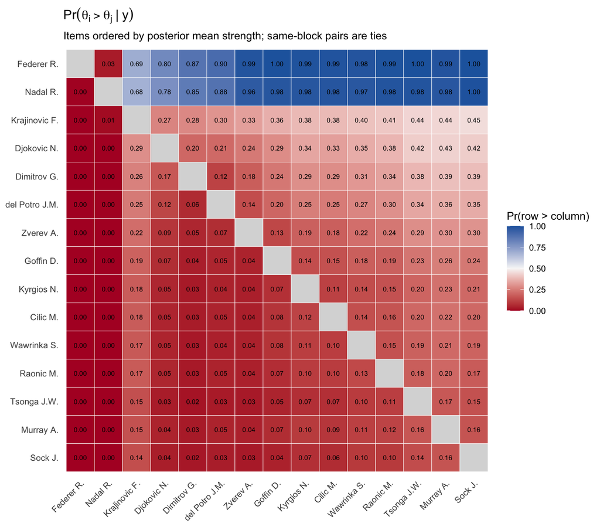

```r
p_atp <- prob_stronger(atp_fit)
atp_equal <- attr(p_atp, "prob_equal")       # Keep ties separate from strict ordering.
federer <- grep("Federer", rownames(p_atp), value = TRUE) # Locate named players.
nadal <- grep("Nadal", rownames(p_atp), value = TRUE)
plot_prob_stronger(atp_fit, max_items = 15) +
  labs(title = expression(Pr(theta[i] > theta[j] ~ "|" ~ y)))
```

Federer and Nadal share a block in 96.7% of retained draws. This pairwise tie frequency can be high even if the estimated top block is rarely reproduced exactly, because other players can join them. Low strict-ordering probabilities can reflect ties, so use `prob_equal` alongside `prob_stronger()`. The displayed 15 players are selected by posterior mean normalised strength, not by their ATP ranking. The metadata field `last_rank` is the last ranking snapshot available for each player in 2017, not necessarily a common year-end date.

### 4.4.1 Exercise: another ATP season

Replace 2017 by 2023. Compare its posterior distribution of K with 2017. A change can reflect a different player pool and schedule as well as strength differences.

The exercise uses distinct object names to preserve the main fit. Run it when it is introduced during the session.

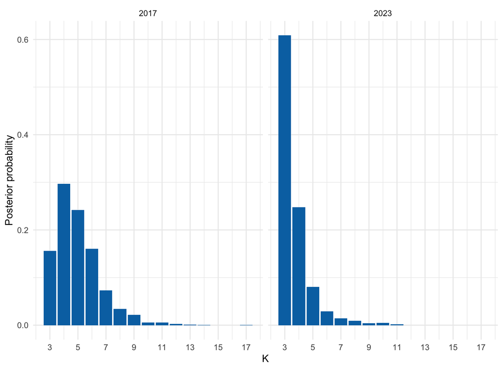

```r
atp_2023 <- ATP_2000_2025[["2023"]]          # Change the year here.
atp_2023_data <- as_bt_data(atp_2023$Y_ij, format = "matrix",
  item_labels = make.unique(atp_2023$players_df$player_label))
atp_2023_fit <- fit_model(atp_2023_data, atp_fit$model, atp_fit$control)
atp_season_comparison <- bind_rows(
  `2017` = posterior_K_table(atp_fit),
  `2023` = posterior_K_table(atp_2023_fit), .id = "season") # Preserve the 2017 fit.
ggplot(atp_season_comparison, aes(K, probability)) +
  geom_col(fill = "#0072B2") +
  facet_wrap(~ season, nrow = 1) +            # Same axes for the two seasons.
  scale_x_continuous(breaks = seq(3, 17, by = 2)) +
  labs(y = "Posterior probability") + theme_minimal()
```

# 5 PL practical: ranked observations

This practical follows the PL theory session.

Rankings record items in order of preference rather than pairwise outcomes. The Plackett–Luce (PL) model chooses the first item with probability proportional to its strength, then the second among those remaining, and so on. We use strict top-five rankings of ten sushi types. `sushi_toy()` is synthetic and generates two preference profiles; it contains no original Sushi Preference Dataset responses. For a first analysis we deliberately fit a single common PL strength vector. This is a pooled model and does not represent the two profiles; mixtures are available for that extension.

```r
sushi <- sushi_toy(n_rankings = 40, rank_length = 5, seed = 3)
positions <- as_tibble(sushi)                 # One reported item-position per row.
positions |> slice_head(n = 5) |> knitr::kable() # The first respondent's top five.
```

| ranking | position | item |
| --- | --- | --- |
| Ranking_1 | 1 | fatty_tuna |
| Ranking_1 | 2 | shrimp |
| Ranking_1 | 3 | inari |
| Ranking_1 | 4 | egg |
| Ranking_1 | 5 | squid |

The long table contains reported positions only. Unreported items in a top-five ranking are below the reported items, but their exact positions are unknown.

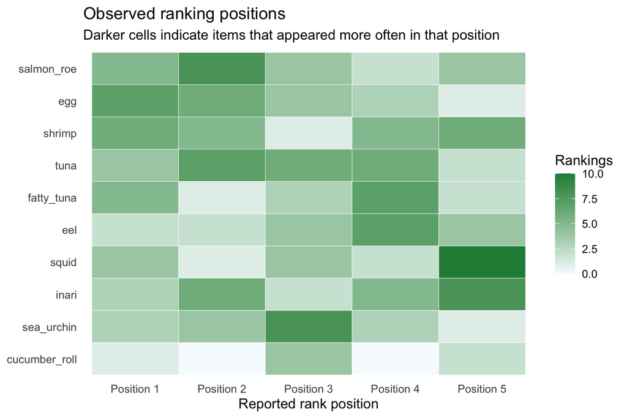

```r
plot_ranking_positions(sushi)
```

### 5.0.1 Explore variation across rankings

Fix set A = {egg, shrimp, cucumber roll, inari}. For ranking $l$, let $C_l$ count set A items in the reported top five. This preserves which items occur together within a respondent’s ranking; a marginal position heatmap does not.

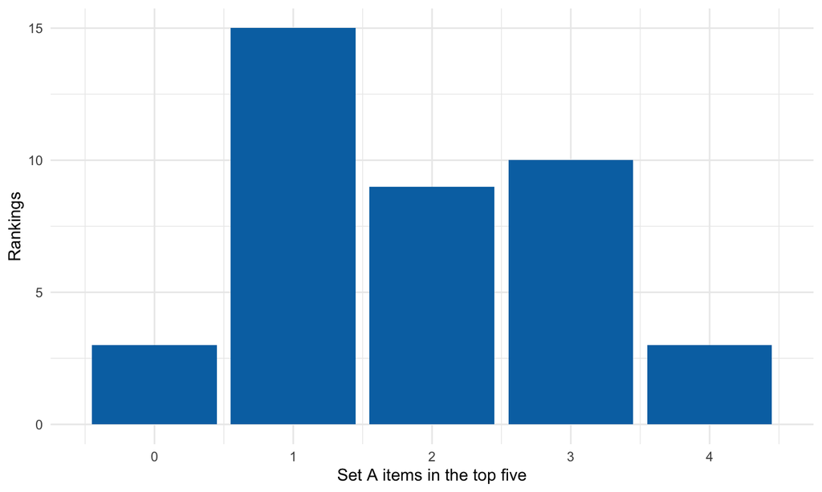

```r
set_A <- c("egg", "shrimp", "cucumber_roll", "inari") # Fixed teaching contrast.
profile_counts <- positions |>
  group_by(ranking) |>                       # Keep each respondent's choices together.
  summarise(in_A = sum(item %in% set_A), .groups = "drop")
ggplot(profile_counts, aes(in_A)) +
  geom_bar(fill = "#0072B2") +
  scale_x_continuous(breaks = 0:4, limits = c(-0.5, 4.5)) +
  labs(x = "Set A items in the top five", y = "Rankings") + theme_minimal()
```

Low and high counts do not themselves establish a mixture. Compare their spread with rankings generated under a single fitted PL model.

```r
pl_fit <- fit_model(sushi, pl_model(shape_lambda = 2), # Gamma shape, as for BT.
  mcmc_control(iter = 2000, warmup = 1000, seed = 4))
summary(pl_fit)
```

```
## Model:   Plackett-Luce (PL), one strength per item
## Data:    10 items, 40 rankings of length 5
## Priors:  lambda_i ~ iid Gamma(shape_lambda = 2, rate_lambda = 1)
## MCMC:    2000 iterations, 1000 warm-up, 1000 retained draws (3.4 s)
##
## Relative strengths (arithmetic mean = 1), 90% credible intervals:
##           item  mean median lower upper
##           tuna 1.358  1.341 0.978 1.808
##     salmon_roe 1.229  1.211 0.878 1.634
##         shrimp 1.159  1.145 0.807 1.538
##            egg 1.145  1.128 0.803 1.536
##          inari 1.143  1.123 0.821 1.527
##          squid 0.954  0.939 0.660 1.311
##     sea_urchin 0.950  0.951 0.640 1.284
##            eel 0.866  0.844 0.587 1.199
##     fatty_tuna 0.864  0.851 0.559 1.172
##  cucumber_roll 0.332  0.318 0.180 0.526
```

As for BT, reported relative strengths have arithmetic mean one across items in each draw. A value of 2 means twice the mean item strength.

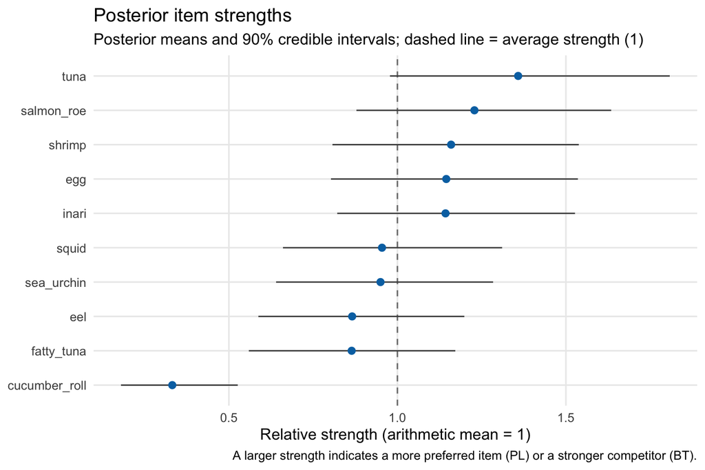

```r
plot_strength_summary(pl_fit)
```

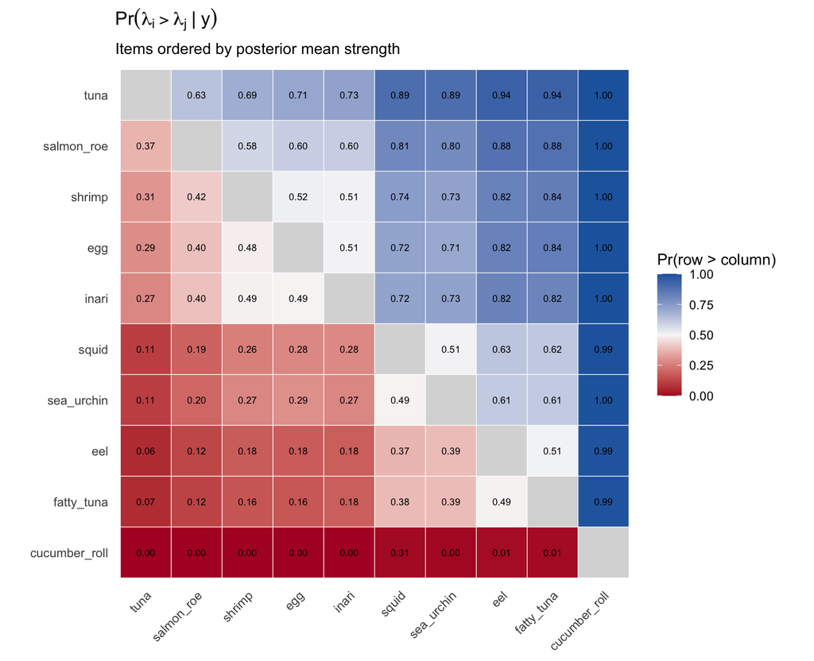

```r
plot_prob_stronger(pl_fit)
```

The same `fit_model()` call also fits PL models with item blocks (`pl_sbm_model()`), groups of ranking rows (`pl_mixture_model()`) or both (`pl_lbm_model()`); see `vignette("pl-ranking-models", package = "RBBayes")`.

# 6 Checking the pooled PL model

Let $T$ be the sample variance of the forty counts $C_l$. For each of 300 posterior draws, simulate forty top-five rankings from the same ten-item universe and recompute $T$. The simulation retains the observation design and includes uncertainty in the fitted strength vector.

```r
set.seed(400)
weights <- posterior_strength(pl_fit, summary = "draws") # One vector per MCMC draw.
set_ids <- match(set_A, sushi$item_labels)               # Translate names to item ids.
replicated_counts <- replicate(300, {
  q <- weights[sample.int(nrow(weights), 1), ]            # Include posterior uncertainty.
  replicate(sushi$n_rankings, {
    top_five <- sample.int(sushi$n_items, sushi$rank_length, prob = q)
    sum(top_five %in% set_ids)                           # Same count as in the data.
  })
})
replicated_variance <- apply(replicated_counts, 2, var)   # One statistic per dataset.
observed_variance <- var(profile_counts$in_A)
```

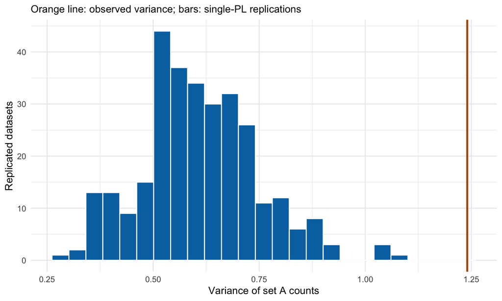

```r
tibble(variance = replicated_variance) |>     # A dataset-level reference distribution.
  ggplot(aes(variance)) +
  geom_histogram(bins = 25, fill = "#0072B2", colour = "white") +
  geom_vline(xintercept = observed_variance, colour = "#b35806", linewidth = 1) +
  labs(x = "Variance of set A counts", y = "Replicated datasets",
       subtitle = "Orange line: observed variance; bars: single-PL replications") +
  theme_minimal()
```

The observed variance is 1.24; the central 90% predictive range is 0.38 to 0.85. 0 out of 300 simulated datasets are at least as variable. Zero simulated exceedances does not mean zero posterior predictive probability.

This pre-specified check shows that one PL vector does not reproduce this aspect of the data well. A mixture is plausible, but the check does not identify the number of preference groups. With real data, examine relevant respondent covariates and several substantively chosen contrasts. Clustering rows can suggest a pattern, but it supplies no calibrated evidence by itself. See [Mollica and Tardella](https://doi.org/10.1007/s11336-016-9530-0) for posterior predictive assessment of models for partial rankings; this particular count-based discrepancy is a teaching example.

## 6.1 Extensions available in RBBayes

`pl_mixture_model()` groups rankings with separate preference vectors; `pl_lbm_model()` jointly groups rankings and items. After fitting a model with ranking groups, `plot_posterior_similarity(fit, target = "ranking")` displays ranking co-membership probabilities. Compare predictive adequacy and stability before interpreting groups.

# 7 Appendix

## 7.1 MCMC run settings

The examples use different run lengths. This table separates total iterations, discarded burn-in and retained draws; no thinning is applied. These settings illustrate the workflow rather than establish that every posterior summary has adequate effective sample size.

```r
fits <- list(BT = bt_fit, BT_SBM_1 = sbm_fit, BT_SBM_2 = sbm_fit2,
             ATP_BT_SBM = atp_fit, PL = pl_fit)
if (has_coda) fits <- append(fits, list(BT_2 = bt_fit2), after = 1)
run_settings <- bind_rows(lapply(names(fits), function(name) { # One row per main fit.
  fit <- fits[[name]]
  tibble(model = name, iterations = fit$control$iter, burn_in = fit$control$warmup,
         retained = nrow(as.matrix(fit)), seed = fit$control$seed)
}))
knitr::kable(run_settings)
```

| model | iterations | burn_in | retained | seed |
| --- | --- | --- | --- | --- |
| BT | 4000 | 2000 | 2000 | 12 |
| BT_2 | 4000 | 2000 | 2000 | 112 |
| BT_SBM_1 | 10000 | 5000 | 5000 | 2 |
| BT_SBM_2 | 10000 | 5000 | 5000 | 202 |
| ATP_BT_SBM | 6000 | 3000 | 3000 | 1 |
| PL | 2000 | 1000 | 1000 | 4 |

## 7.2 Bayesplot diagnostics

These examples use the same normalised BT-strength draws as the coda section. The trace plot shows two player parameters; the interval plot shows posterior intervals for the four selected players. The bayesplot examples are skipped when `bayesplot` is not installed and does not depend on `coda` being available.

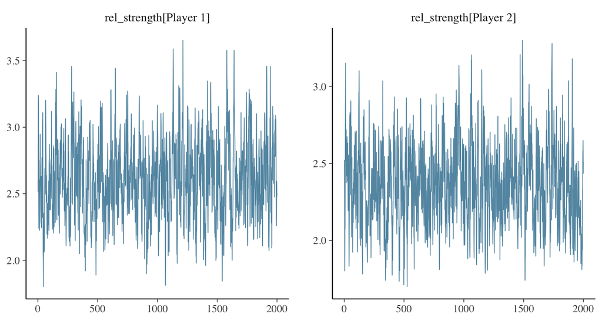

```r
top_players <- strength_summary(bt_fit) |>
  slice_head(n = 4) |>                       # Select the same four player parameters.
  transmute(parameter = paste0("rel_strength[", item, "]")) |>
  pull(parameter)
bayesplot::mcmc_trace(bt_fit, pars = top_players[1:2])
```

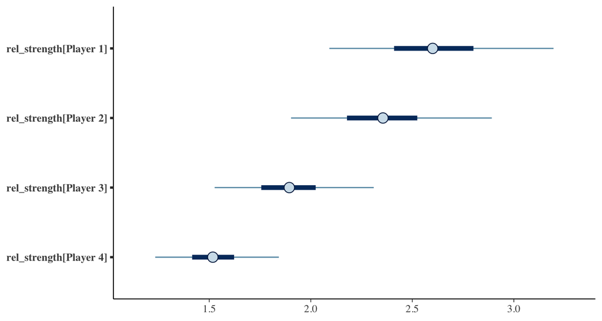

```r
bayesplot::mcmc_intervals(bt_fit, pars = top_players, prob = 0.5, prob_outer = 0.95)
```